# Digital_soil_mapping

Flueckiger_Rubens

2025-11-05

# 1 Packages

To solve the report exercise, the following packages will be needed.

```r
library(ggplot2)
library(dplyr)
library(tidyr)
library(ranger)
library(caret)
library(plotROC)
```

# 2 Load data sets

To implement the random forest model we will need the following data set.

```r
df <- readRDS("../data_raw/df_digital_soil_mapping.rds")
```

# 3 Simple model

In a first step we will re-implement the workflow given in the *Digital Soil Mapping* chapter. However, instead of specially predicting the pH at the top 10cm `pH.0.10` we will model whether the soil is waterlogged at a depth of 100cm `waterlog.100` or not.

> **Note**

> The variable `waterlog.100` is categorical/binary. It can only obtain two values; 1 if it is waterlogged at 100cm depth and 0 if not.

## 3.1 Preprocessing

To simplify the selection of variables needed to perform a *Random Forest* modelling we first define the target variable (here: `waterlog.100`) and the necessary variables we will apply the model on.

```r
# Specify target
target <- "waterlog.100"

# Specify predictors
predictors <- names(df)[14:ncol(df)]
```

Then we will split the data set into a training set and a test set. As the data set already comes with calibration and validation sites, we will use the calibration sites as our training data sets and the validation sites as our test set. To guarantee no complications while performing the Random Forest classification, we will drop all `NA` values.

```r
df_train <- df |> filter(dataset == "calibration") |> drop_na()
df_test <- df |> filter(dataset == "validation") |> drop_na()
```

## 3.2 Model training

Now we can start modelling. Since the target variable (`waterlog.100`) is categorical, we will need to specify the character of the vector as categorical by using the function `factor()`. In addition we will return basic information about the model, such as the out-of-the-bag error OOB, which will be useful for the interpretation of the result later on.

```r
rf_basic <- ranger(
  formula = factor(df_train[, target]) ~ ., # Model formula
  data = df_train[, predictors], # Target variable
  seed = 42,  # Seed for randomization to reproduce the same model
  num.threads = parallel::detectCores() - 1 # Use all but 1 CPU core for quick model training
)

# quick report and performance of trained model object
rf_basic
```

```
## Ranger result
##
## Call:
##  ranger(formula = factor(df_train[, target]) ~ ., data = df_train[,      predictors], seed = 42, num.threads = parallel::detectCores() -      1)
##
## Type:                             Classification
## Number of trees:                  500
## Sample size:                      605
## Number of independent variables:  91
## Mtry:                             9
## Target node size:                 1
## Variable importance mode:         none
## OOB prediction error:             21.32 %
```

## 3.3 Model evaluation

To evaluate the model, we will apply the generated Random Forest model on the test set separated in chapter 3.1 Preprocessing.

```r
# Predict waterlog.100 on test set
rf_eval <- predict(
  rf_basic, # Model
  data = df_test, # test set
  num.threads = parallel::detectCores() - 1
)

# Save predictions to validation df
df_eval <- data.frame(df_test$waterlog.100) # Observed
df_eval$pred <- rf_eval$predictions # Predicted

# Rename column
df_eval <- df_eval |>
  rename("waterlog.100" = "df_test.waterlog.100")
```

To analyse the result, we can use the `confusionMatrix()` function of the package `caret`. The function creates a confusion matrix (true positive, true negative, false positive and false negative values) as well as statistical analysis of the categorical data set such as Sensitivity, Specificity and Balanced Accuracy values.

```r
conf_matrix <- confusionMatrix(
  data = df_eval$pred, # Predicted values
  reference = as.factor(df_eval$waterlog.100), # Observed values
  dnn = c("Predicted", "Observed") # Axis names of confusion matrix
)

# Quick report of statistical analysis
conf_matrix
```

```
## Confusion Matrix and Statistics
##
##          Observed
## Predicted   0   1
##         0 104  23
##         1  26  47
##
##                Accuracy : 0.755
##                  95% CI : (0.6894, 0.8129)
##     No Information Rate : 0.65
##     P-Value [Acc > NIR] : 0.0009148
##
##                   Kappa : 0.4668
##
##  Mcnemar's Test P-Value : 0.7750970
##
##             Sensitivity : 0.8000
##             Specificity : 0.6714
##          Pos Pred Value : 0.8189
##          Neg Pred Value : 0.6438
##              Prevalence : 0.6500
##          Detection Rate : 0.5200
##    Detection Prevalence : 0.6350
##       Balanced Accuracy : 0.7357
##
##        'Positive' Class : 0
##
```

To analyse whether the test set is balanced or not, we will simply group by the waterlogged (1) and not waterlogged (0) cases and summaries them by taking the sum. If the test set is balanced, there should be about as many waterlogged as not waterlogged cases.

```r
# Test set
balance_test <- df_eval |>
  group_by(waterlog.100) |> # Group by observations
  summarise(count_test = n()) # Count all 0's and 1's

# Training set
balance_train <- df_train |>
  group_by(waterlog.100) |> # Group by waterlog.100
  summarise(count_train = n())

# Generate table for visualisation
balance <- merge(balance_test, balance_train, by = "waterlog.100")
knitr::kable(
  balance, # df
  align = "lcc", # Align columns
  caption = "Table 1: Number of observations being waterlogged (1) or not waterlogged (0) for the test and training set", # Table name
  col.names = c("Waterlogged", "Amount in test set", "Amount in training set") # Column names
)
```

Table 1: Number of observations being waterlogged (1) or not waterlogged (0) for the test and training set

| Waterlogged | Amount in test set | Amount in training set |
| --- | --- | --- |
| 0 | 130 | 358 |
| 1 | 70 | 247 |

As one can see, the training and test set are skewed towards not waterlogged sites. This has a huge effect on the model performance. Assuming we have a data set with 90% containing only 1’s and the remaining 10% only 0’s. This means that if we create a model that always predicts 1, we would achieve an accuracy of 90%. This obviously is not desired when implementing a model and has to be accounted for.

# 4 Variable selection

In this chapter, we will select only those variables which yield the most importance in explaining the target variable (`waterlog.100`) and compare the result with the result given in chapter 3 Simple model.

## 4.1 Select variables

To select the most explaining variables I will use the `Boruta` package. In addition I will return the hierarchy of importance of each variable.

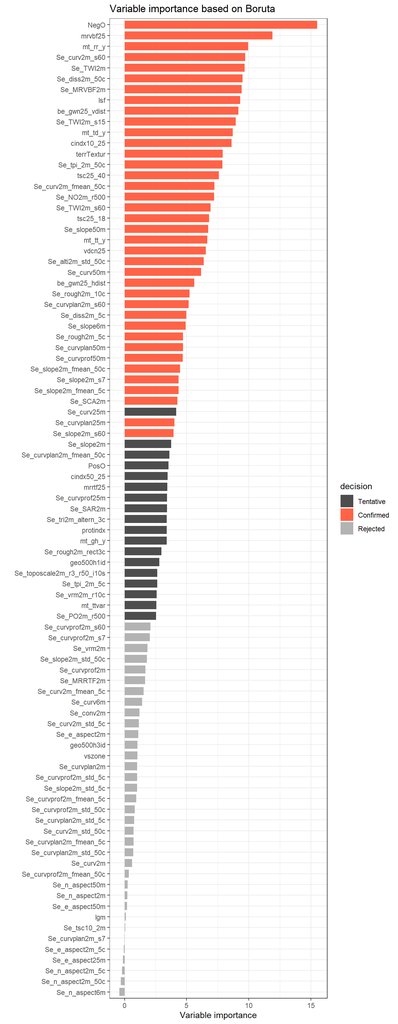

Figure 1: Variable selection based on the Boruta package

```r
set.seed(42)

# run the algorithm
bor <- Boruta::Boruta(
    y = df_train[, target], # Target variable
    x = df_train[, predictors], # All available predictors
    maxRuns = 50, # Number of iterations. Set to 30 or lower if it takes too long
    num.threads = parallel::detectCores()-1)

# obtain results: a data frame with all variables, ordered by their importance
df_bor <- Boruta::attStats(bor) |>
  tibble::rownames_to_column() |>
  arrange(dplyr::desc(meanImp))

# plot the importance result
ggplot(data = df_bor, aes(x = reorder(rowname, meanImp),
                          y = meanImp,
                          fill = decision)) +
  geom_bar(stat = "identity", width = 0.75) +
  scale_fill_manual(values = c("grey30", "tomato", "grey70")) +
  labs(
    x = "",
    y = "Variable importance",
    title = "Variable importance based on Boruta"
  ) +
  theme_bw() +
  coord_flip()
```

Given the selection above, we can now create a vector only containing the most explaining variables. Hereby we will use the `filter` function of `dplyr` package and extract row names from the resulting data frame above.

```r
predictors_selected <- df_bor |>
  filter(decision == "Confirmed") |> # Filter all variables with "confirmed"
  pull(rowname) # Extract rownames from it
```

## 4.2 Train new model

> **Note**

> We again need to use the function `factor` to specify the `waterlog.100` variable as categorical.

```r
rf_bor <- ranger(
  formula = factor(df_train[, target]) ~ ., # target variable
  data = df_train[, predictors_selected], # Predictor variables
  seed = 42, # Specify the seed for randomization to reproduce the same model again
  num.threads = parallel::detectCores() - 1)

# quick report and performance of trained model object
rf_bor
```

```
## Ranger result
##
## Call:
##  ranger(formula = factor(df_train[, target]) ~ ., data = df_train[,      predictors_selected], seed = 42, num.threads = parallel::detectCores() -      1)
##
## Type:                             Classification
## Number of trees:                  500
## Sample size:                      605
## Number of independent variables:  38
## Mtry:                             6
## Target node size:                 1
## Variable importance mode:         none
## OOB prediction error:             20.99 %
```

## 4.3 Evaluate new model

Now we can repeat the same step as in chapter 3.3 Model evaluation.

```r
rf_eval_vs <- predict(
  rf_bor,           # RF model
  data = df_test,   # Predictor data
  num.threads = parallel::detectCores() - 1
)

# Save predictions to validation df
df_eval_vs <- data.frame(df_test$waterlog.100)
df_eval_vs$pred <- rf_eval_vs$predictions

# Rename column
df_eval_vs <- df_eval_vs |>
  rename("waterlog.100" = "df_test.waterlog.100")
```

Again we will use the `confusionMatrix()` function to summarise the result.

```r
conf_matrix_vs <- confusionMatrix(
  data = df_eval_vs$pred,
  reference = as.factor(df_eval_vs$waterlog.100),
  dnn = c("Predicted", "Observed")
)
conf_matrix_vs
```

```
## Confusion Matrix and Statistics
##
##          Observed
## Predicted   0   1
##         0 105  19
##         1  25  51
##
##                Accuracy : 0.78
##                  95% CI : (0.7161, 0.8354)
##     No Information Rate : 0.65
##     P-Value [Acc > NIR] : 4.557e-05
##
##                   Kappa : 0.5259
##
##  Mcnemar's Test P-Value : 0.451
##
##             Sensitivity : 0.8077
##             Specificity : 0.7286
##          Pos Pred Value : 0.8468
##          Neg Pred Value : 0.6711
##              Prevalence : 0.6500
##          Detection Rate : 0.5250
##    Detection Prevalence : 0.6200
##       Balanced Accuracy : 0.7681
##
##        'Positive' Class : 0
##
```

```r
# Create table for visualisation
metric <- c("Sensitivity", "Specificity", "PPV", "NPV", "F1", "Balanced Accuracy", "OOB")
df_metric <- data.frame(metric)

simple_model <- c( # Metrics of simple model
  round(conf_matrix$byClass[c(1:4, 7, 11)], 4), # Everything but OOB
  round(rf_basic$prediction.error, 4) # OOB
)

vs_model <- c( # Metrics of variable selection model
  round(conf_matrix_vs$byClass[c(1:4, 7, 11)], 4), # Everything but OOB
  round(rf_bor$prediction.error, 4) # OOB
)

# Add metrics to df
df_metric[, "simple_model"] <- simple_model # Add simple model
df_metric[, "vs_model"] <- vs_model # Add vs model

# Create table with knitr::kable
knitr::kable(
  df_metric, # df
  align = "lcc", # align columns
  caption = "Table 2: Compareing statistics of the simple model created in chapter 3 and the variable selection (VS) model in this chapter", # Table name
  col.names = c("Metric", "Simple Model", "VS Model") # column names
)
```

Table 2: Compareing statistics of the simple model created in chapter 3 and the variable selection (VS) model in this chapter

| Metric | Simple Model | VS Model |
| --- | --- | --- |
| Sensitivity | 0.8000 | 0.8077 |
| Specificity | 0.6714 | 0.7286 |
| PPV | 0.8189 | 0.8468 |
| NPV | 0.6438 | 0.6711 |
| F1 | 0.8093 | 0.8268 |
| Balanced Accuracy | 0.7357 | 0.7681 |
| OOB | 0.2132 | 0.2099 |

As one can see from the table above, the model with selected variables generalizes better given every metric above. Additionally the OOB is specified. Since the OOB of the model with selected variables is lower than the OOB of the simple model, the model with selected variables would still be chosen, as a lower OOB score describes a more accurate model.

# 5 Model optimization

The aim of this chapter is to improve the initial simple model by tweaking the hyperparamteres `mtry` and `min.node.size` with the help of the `caret` package.

## 5.1 Hyperparameter adjustment

Finally we want to optimize the model by tweaking the `mtry` and `min.node.size` parameters of the `ranger` model function. Hereby we will use the `caret` package. In a first step however, we need to specify all dependent variables on our target variables and convert that into a `caret` readable format with the `formula()` function.

```r
# Create string with all variables
fun_pred <- paste(
  c("waterlog.100 ~", paste(predictors, collapse = " + ")),
  collapse = " "
)

# Convert into a caret-readable string
fun_pred <- formula(fun_pred)
```

Now we can use the `train` function of `caret` to model the the function over the training data set. with the `trainControl()` function we can specify how we want to tweak the hyperparameters. Here we select cv; Cross-Validation and with number we specify how many Cross-Validations we perform (here: 5). With the `tuneGrid` input we can specify the arguments to be tweaked (here: `mtry` and `min.node.size`. I held `splitrule` as variance). To reduce run time of the code, I only selected a few values.

> **Note**

> `caret::train` realizes that the outcome variable `waterlog.100` is categorical and hints us towards using the `factor()` function to specify the variable as such. However, since `caret::train` already realized that `waterlog.100` is categorical, it is not necessary to specify it again. Thereby we can simply ignore the warning message.

```r
mod_cv <- train(
  fun_pred, # Model function
  data = df_train, # training set
  method = "ranger", # Random Forest model
  trControl = trainControl(
    method = "cv", # Cross-Validation method
    number = 5, # 5-Fold CV
    savePredictions = "final"
  ),
  tuneGrid = data.frame(
    .mtry = c(1, 2, 3, 4, 5, 10, 20, 30, 40, 50, 60, 70, 80),
    .min.node.size = c(1, 10, 20, 30, 40, 50, 100, 150, 200, 250, 300, 400, 500),
    .splitrule = "variance"
  ),
  metric = "MAE" # LOESS function
)
mod_cv
```

```
## Random Forest
##
## 605 samples
##  91 predictor
##
## No pre-processing
## Resampling: Cross-Validated (5 fold)
## Summary of sample sizes: 484, 484, 484, 484, 484
## Resampling results across tuning parameters:
##
##   mtry  min.node.size  RMSE       Rsquared   MAE
##    1      1            0.4058873  0.3556727  0.3629954
##    2     10            0.3971043  0.3625110  0.3371525
##    3     20            0.3954194  0.3661427  0.3326498
##    4     30            0.3939496  0.3709409  0.3306529
##    5     40            0.3935722  0.3716058  0.3291380
##   10     50            0.3925446  0.3723545  0.3235490
##   20    100            0.3940369  0.3676625  0.3247299
##   30    150            0.3963000  0.3608019  0.3281255
##   40    200            0.3974966  0.3572560  0.3313825
##   50    250            0.4010773  0.3486290  0.3407496
##   60    300            0.4076845  0.3285954  0.3520385
##   70    400            0.4131895  0.3100914  0.3591754
##   80    500            0.4920424        NaN  0.4836007
##
## Tuning parameter 'splitrule' was held constant at a value of variance
## MAE was used to select the optimal model using the smallest value.
## The final values used for the model were mtry = 10, splitrule = variance
##  and min.node.size = 50.
```

The resulting optimal values for the hyperparamters are:

- `mtry`: 10
- `min.node.size`: 50

## 5.2 Train optimized model

To train the new model we simply repeat the step as in chapters 3.2 Model training and 4.2 Train new model and add `mtry` and `min.node.size` values from chapter 5.1 Hyperparameter adjustment.

```r
rf_optim <- ranger(
  formula = factor(df_train[, target]) ~ ., # target variable
  data = df_train[, predictors_selected], # Predictor variables
  mtry = 10, # Given from above
  min.node.size = 50, # Given from above
  seed = 42, # Specify the seed for randomization to reproduce the same model again
  num.threads = parallel::detectCores() - 1)

# quick report and performance of trained model object
rf_optim
```

```
## Ranger result
##
## Call:
##  ranger(formula = factor(df_train[, target]) ~ ., data = df_train[,      predictors_selected], mtry = 10, min.node.size = 50, seed = 42,      num.threads = parallel::detectCores() - 1)
##
## Type:                             Classification
## Number of trees:                  500
## Sample size:                      605
## Number of independent variables:  38
## Mtry:                             10
## Target node size:                 50
## Variable importance mode:         none
## OOB prediction error:             21.65 %
```

## 5.3 Evaluate optimized model

To evaluate the optimized model we can repeat the process from chapter 3.3 Model evaluation or 4.3 Evaluate new model.

```r
rf_eval_optim <- predict(
  rf_optim, # RF model
  data = df_test, # Predictor data
  num.threads = parallel::detectCores() - 1
)

# Save predictions to validation df
df_eval_optim <- data.frame(df_test$waterlog.100)
df_eval_optim$pred <- rf_eval_optim$predictions

# Rename column
df_eval_optim <- df_eval_optim |>
  rename("waterlog.100" = "df_test.waterlog.100")
```

Again we will use the `confusionMatrix()` function to summarise the result.

```r
conf_matrix_optim <- confusionMatrix(
  data = df_eval_optim$pred,
  reference = as.factor(df_eval_optim$waterlog.100),
  dnn = c("Predicted", "Observed")
)
conf_matrix_optim
```

```
## Confusion Matrix and Statistics
##
##          Observed
## Predicted   0   1
##         0 107  20
##         1  23  50
##
##                Accuracy : 0.785
##                  95% CI : (0.7215, 0.8398)
##     No Information Rate : 0.65
##     P-Value [Acc > NIR] : 2.306e-05
##
##                   Kappa : 0.5321
##
##  Mcnemar's Test P-Value : 0.7604
##
##             Sensitivity : 0.8231
##             Specificity : 0.7143
##          Pos Pred Value : 0.8425
##          Neg Pred Value : 0.6849
##              Prevalence : 0.6500
##          Detection Rate : 0.5350
##    Detection Prevalence : 0.6350
##       Balanced Accuracy : 0.7687
##
##        'Positive' Class : 0
##
```

```r
optim_model <- c( # Metrics of optimized model
  round(conf_matrix_optim$byClass[c(1:4, 7, 11)], 4), # Everything but OOB
  round(rf_optim$prediction.error, 4) # OOB
)

# Add metrics to df
df_metric[, "optimized_model"] <- optim_model # Add optimized model

# Create table with knitr::kable
knitr::kable(
  df_metric, # df
  align = "lccc", # align columns
  caption = "Table 3: Compareing statistics of the simple model created in chapter 3, the variable selection (VS) model in chapter 4 and the optimized hyperparameter model in this chapter", # Table name
  col.names = c("Metric", "Simple Model", "VS Model", "Optimized Model") # column names
)
```

Table 3: Compareing statistics of the simple model created in chapter 3, the variable selection (VS) model in chapter 4 and the optimized hyperparameter model in this chapter

| Metric | Simple Model | VS Model | Optimized Model |
| --- | --- | --- | --- |
| Sensitivity | 0.8000 | 0.8077 | 0.8231 |
| Specificity | 0.6714 | 0.7286 | 0.7143 |
| PPV | 0.8189 | 0.8468 | 0.8425 |
| NPV | 0.6438 | 0.6711 | 0.6849 |
| F1 | 0.8093 | 0.8268 | 0.8327 |
| Balanced Accuracy | 0.7357 | 0.7681 | 0.7687 |
| OOB | 0.2132 | 0.2099 | 0.2165 |

# 6 Probabilistic predictions

The aim of this chapter is to create a Reicever-operating-characteristic (ROC) curve given a probailistical prediction of a soil being waterlogged.

## 6.1 Train probabilistic model

To model if a soil is waterlogged probabilisticaly, we can apply the same model as in chapter 5.2 Train optimized model and add the `probability = TRUE` statement to the `ranger()` function.

```r
rf_prob <- ranger(
  formula = factor(df_train[, target]) ~ ., # target variable
  data = df_train[, predictors_selected], # Predictor variables
  mtry = 10, # Given from chapter 5.1
  min.node.size = 50, # Given from chapter 5.1
  seed = 42, # Specify the seed for randomization to reproduce the same model again
  probability = TRUE, # yields a probability to be true
  num.threads = parallel::detectCores() - 1)

# quick report and performance of trained model object
rf_prob
```

```
## Ranger result
##
## Call:
##  ranger(formula = factor(df_train[, target]) ~ ., data = df_train[,      predictors_selected], mtry = 10, min.node.size = 50, seed = 42,      probability = TRUE, num.threads = parallel::detectCores() -          1)
##
## Type:                             Probability estimation
## Number of trees:                  500
## Sample size:                      605
## Number of independent variables:  38
## Mtry:                             10
## Target node size:                 50
## Variable importance mode:         none
## OOB prediction error:             0.1460369
```

## 6.2 ROC curve

To create the ROC curve we need to apply the model onto the test set. The resulting data will now no longer be in a binary form but in a continuous form, where the values range from zero to one and representing the probability for a soil to be 0 (or not waterlogged) or 1 (or waterlogged). Note that the sum of both always must equal 1.

```r
rf_eval_prob <- predict(
  rf_prob, # RF model
  data = df_test, # Predictor data
  num.threads = parallel::detectCores() - 1
)

# Save predictions to validation df
df_eval_prob <- data.frame(df_test$waterlog.100)
df_eval_prob$pred_0 <- rf_eval_prob$predictions[, "0"]
df_eval_prob$pred_1 <- rf_eval_prob$predictions[, "1"]

# Rename column
df_eval_prob <- df_eval_prob |>
  rename("waterlog.100" = "df_test.waterlog.100")
```

To create the ROC curve we will now only consider the probability of a soil to be waterlogged. To display the ROC curve we will use the `plotROC` package. This will enable the `geom_roc()` function in `ggplot2`. To create the ROC curve, we will use the observed variable `waterlog.100` of the evaluation data frame as the disease variable (denoted as d in the `aes()` argument in `ggplot2`) and the probability of being waterlogged (I named it pred_1 in the evaluation data frame) as the marker variable (denoted as m in the `aes()` argument in `ggplot2`).

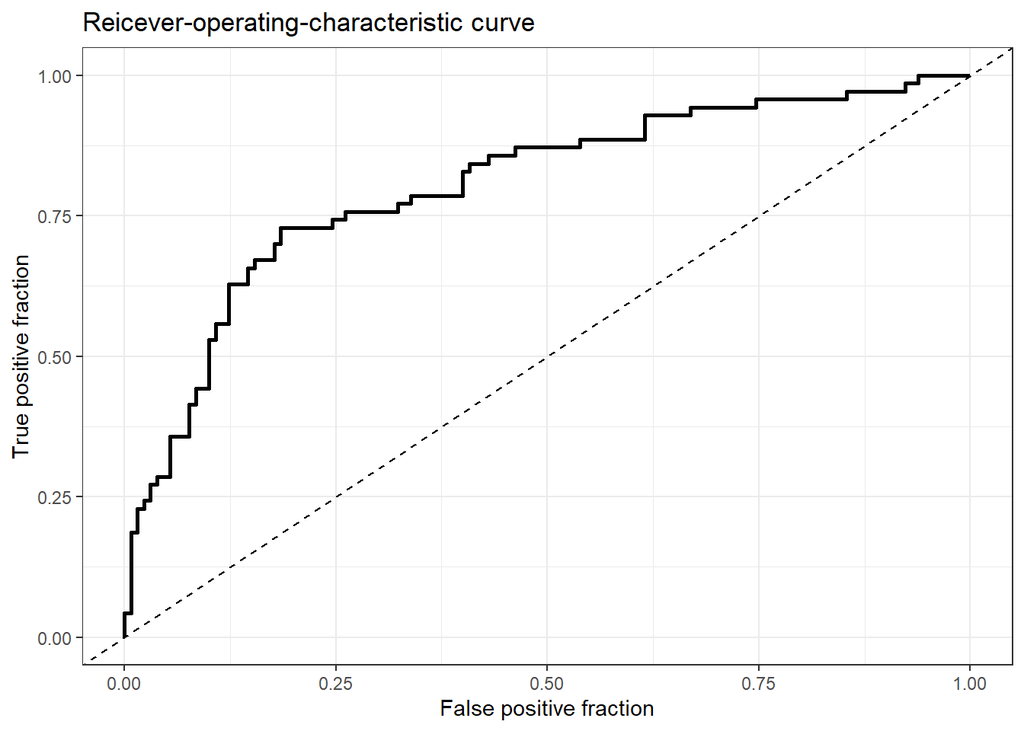

Figure 2: Reicever-operating-characteristic (ROC) curve of the optimized hyperparamter model with probabilistic chance of the soil being waterlogged

```r
ggplot(data = df_eval_prob, aes(d = waterlog.100, m = pred_1)) +
  geom_roc(n.cuts = 0, labels = FALSE) + # Add ROC curve & remove label and marker
  geom_abline( # Random guess line
    intercept = 0,
    slope = 1,
    linetype = "dashed"
  ) +
  labs(
    x = "False positive fraction",
    y = "True positive fraction",
    title = "Reicever-operating-characteristic curve"
  ) +
  theme_bw()
```

The resulting curve (solid black line) clearly displays a better than “random guess” model, denoted as the dashed line.

## 6.3 Additional questions

The threshold value chosen to determine whether a soil should be attributed to a waterlogged soil or not can be used to limit false predictions. Assuming we will use the probability of a soil being waterlogged, lowering the threshold means a less strict attribution which leads to more falsely waterlogged-attributed soils. Therefore, lowering the threshold leads to a higher risk of type 2 errors. On the other hand increasing the threshold means a more strict attribution which leads to more falsely not-waterlogged attributed soils. This leads to more type 1 errors. In the case of retaining building integrity by making sure that the soil is not waterlogged, it therefore would be advisable to increase the threshold value. For building sites, were waterlogged soils are unwanted but not critical, the threshold values can be lowered since the prime not waterlogged sites may already be reserved or taken by critical infrastructures, which must be build in non-waterlogged sites. However, the threshold value for unwanted waterlogged sites is highly variable and strongly depends on the wish of the builder.

A similar-natured problem arises in remote sensing. When measuring the sea ice extend in polar regions a pixel usually contains both sea ice and water. Since water has a much lower albedo compared to ice, this drastically affects the resulting reflectance of a specific band (and its polarization) used to determine the extend and hence returning us a percentage of ice-covered water (using the NASA algorithm for instant). When determining the actual extend of the sea ice at a certain time we would need a threshold value of sea ice covered water for which we would attribute a pixel to be sea ice covered or not.